# ゲームハード週販レポート (2025.12.28)

国内ゲームハード週販レポート (2025-12-28)

- ハードウェアの販売データはファミ通の調査結果を基にしています。
- 一部のデータは処理上の都合により、週次値に調整しています。
- 過去の週販レポート

## 直近4週間のハード売り上げ／累計推移

Switch2の2025年最終週は20万台でした｡今年5回目の20万台超えです｡ 任天堂は12月をSwitch2大量出荷で完遂しました｡ 今後は2026年に入ってからの出荷状況に注目です｡

Switchは微減の3.2万台｡世代交代が進んでいます｡

PS5は3週連続で約1万9千台です｡ このブレの無さは何なんでしょうか｡

| 集計日 | ハード | 販売台数 | 累計台数 |
| --- | --- | --- | --- |
| 2025-12-07 | Nintendo Switch2 | 203,398 | 3,171,833 |
|  | Nintendo Switch | 51,316 | 36,313,858 |
|  | PlayStation5 | 25,240 | 7,240,759 |
|  | Xbox Series X\|S | 231 | 688,890 |
|  | PlayStation4 | 20 | 9,491,007 |
| 2025-12-14 | Nintendo Switch2 | 190,944 | 3,362,777 |
|  | Nintendo Switch | 31,344 | 36,345,202 |
|  | PlayStation5 | 18,912 | 7,259,671 |
|  | Xbox Series X\|S | 183 | 689,073 |
|  | PlayStation4 | 13 | 9,491,020 |
| 2025-12-21 | Nintendo Switch2 | 221,033 | 3,583,810 |
|  | Nintendo Switch | 38,184 | 36,383,386 |
|  | PlayStation5 | 19,307 | 7,278,978 |
|  | Xbox Series X\|S | 184 | 689,257 |
|  | PlayStation4 | 12 | 9,491,032 |
| 2025-12-28 | Nintendo Switch2 | 200,257 | 3,784,067 |
|  | Nintendo Switch | 32,775 | 36,416,161 |
|  | PlayStation5 | 19,232 | 7,298,210 |
|  | Xbox Series X\|S | 297 | 689,554 |
|  | PlayStation4 | 15 | 9,491,047 |

## 週販推移

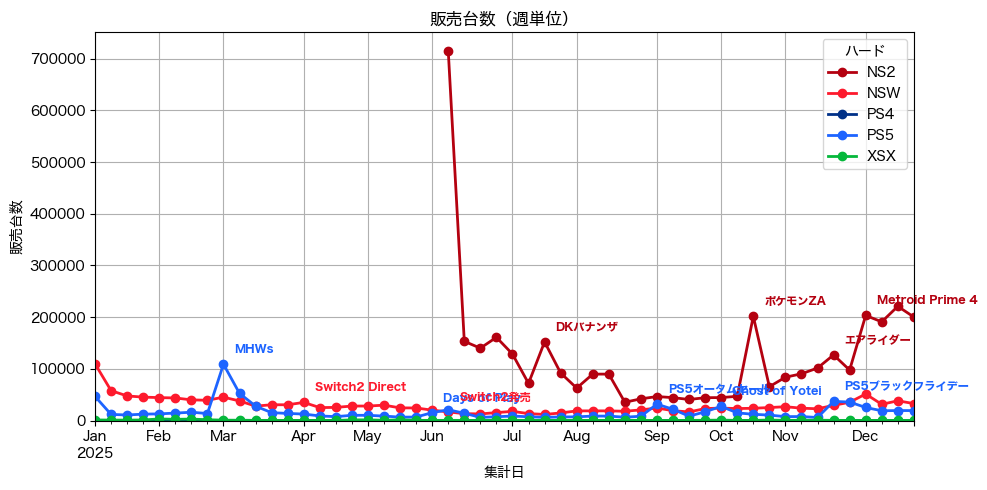

### 週販推移(拡大）

Switch2は年末商戦を大量出荷で締めくくりました｡ 年始の1週目も同程度と予想しますが､その後は減少するでしょう｡

年始明けでSwitchは本格的に減少するでしょう｡ 今までのSwitch週販最低記録は 2025/7/25の11,766台です｡2月あたりには4桁が見えてきそうです｡

PS5は不思議な低水準の安定が続いています｡ これがクリスマスシーズンだけなのか､2026年も続くのか注目です｡

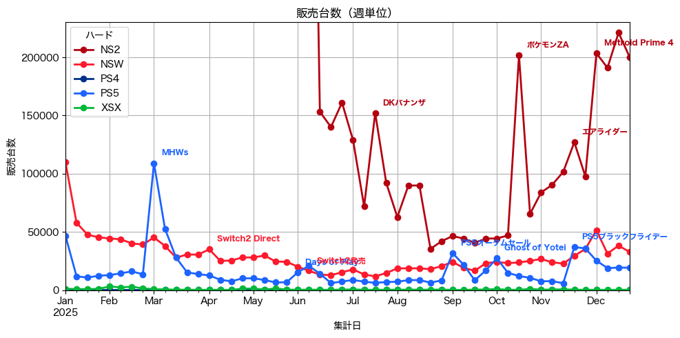

## 月間販売推移

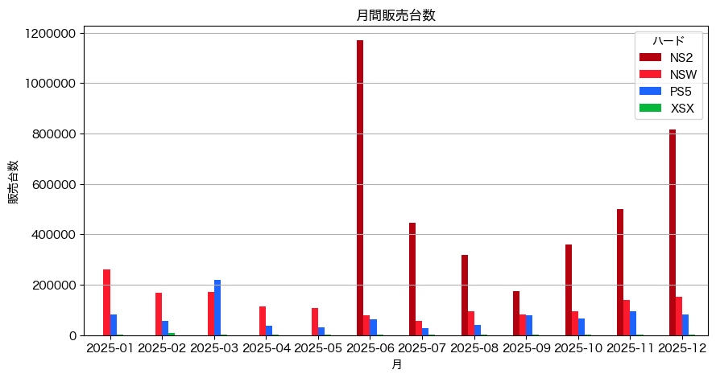

12月のSwitch2は81万台に到達｡任天堂は2025Q3に167万台を販売しました｡

| hw year_month | NS2 | NSW | PS5 | XSX |
| --- | --- | --- | --- | --- |
| 2025-01 | 0 | 260,447 | 81,587 | 3,861 |
| 2025-02 | 0 | 167,188 | 56,886 | 9,751 |
| 2025-03 | 0 | 171,921 | 218,300 | 2,081 |
| 2025-04 | 0 | 113,513 | 38,983 | 1,710 |
| 2025-05 | 0 | 106,506 | 32,001 | 3,467 |
| 2025-06 | 1,169,684 | 78,097 | 63,516 | 1,400 |
| 2025-07 | 444,706 | 57,532 | 28,959 | 1,197 |
| 2025-08 | 319,690 | 94,517 | 39,004 | 1,599 |
| 2025-09 | 175,542 | 82,946 | 78,693 | 1,121 |
| 2025-10 | 358,399 | 96,080 | 64,732 | 2,253 |
| 2025-11 | 500,414 | 138,018 | 93,852 | 1,891 |
| 2025-12 | 815,632 | 153,619 | 82,691 | 895 |

### Nintendo Switchの月間販売台数： 2023,2024年との比較

12月の前年比は34%(予想33%)になりました｡ SwitchからSwitch2へのシフトは順調で､2026年は前年比50%を切るのが普通になるでしょう｡

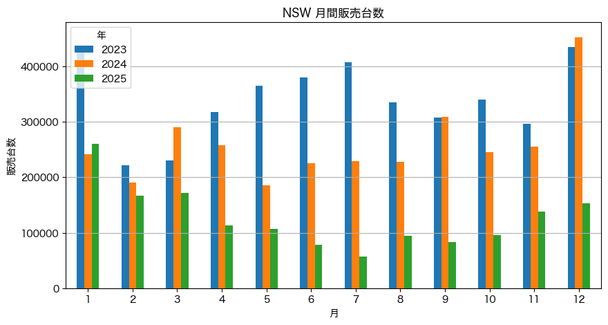

| year month | 2024 | 2025 | YoY |
| --- | --- | --- | --- |
| 1 | 241282 | 260447 | 107.9% |
| 2 | 190786 | 167188 | 87.6% |
| 3 | 289673 | 171921 | 59.4% |
| 4 | 257515 | 113513 | 44.1% |
| 5 | 185821 | 106506 | 57.3% |
| 6 | 225316 | 78097 | 34.7% |
| 7 | 229316 | 57532 | 25.1% |
| 8 | 227913 | 94517 | 41.5% |
| 9 | 308404 | 82946 | 26.9% |
| 10 | 245466 | 96080 | 39.1% |
| 11 | 255401 | 138018 | 54.0% |
| 12 | 452210 | 153619 | 34.0% |

### PlayStation 5の月間販売台数： 2023, 2024年との比較

PS5の2025年12月は予想通り8万2千台にとどまりました｡前年比51%なのでほぼ半減です｡

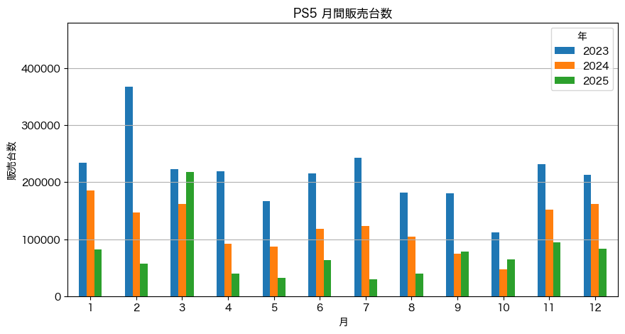

| year month | 2024 | 2025 | YoY |
| --- | --- | --- | --- |
| 1 | 185480 | 81587 | 44.0% |
| 2 | 146945 | 56886 | 38.7% |
| 3 | 162281 | 218300 | 134.5% |
| 4 | 91981 | 38983 | 42.4% |
| 5 | 87218 | 32001 | 36.7% |
| 6 | 117592 | 63516 | 54.0% |
| 7 | 123087 | 28959 | 23.5% |
| 8 | 104178 | 39004 | 37.4% |
| 9 | 74523 | 78693 | 105.6% |
| 10 | 47615 | 64732 | 135.9% |
| 11 | 151370 | 93852 | 62.0% |
| 12 | 161879 | 82691 | 51.1% |

## 累計販売推移

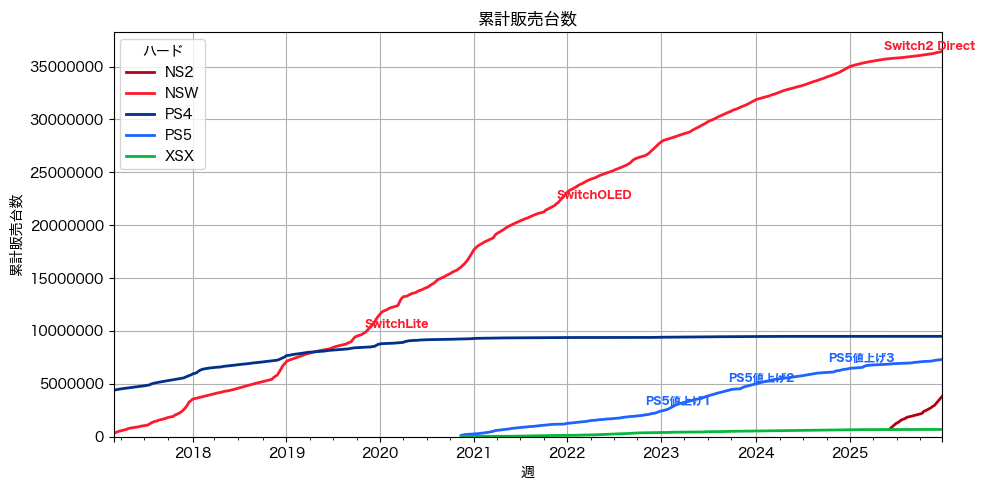

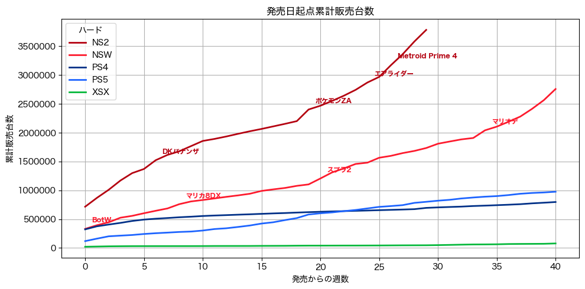

### Switch2/PS5差分

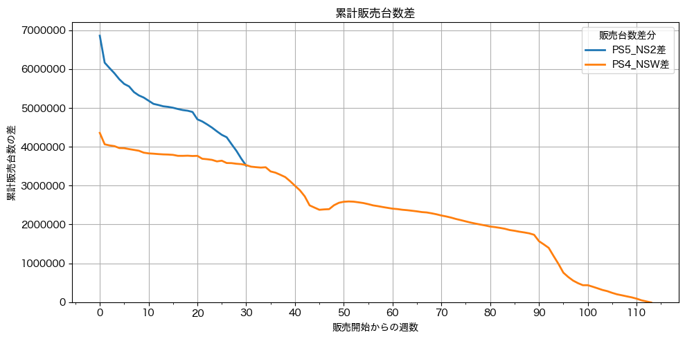

## Switch2初動状況

Switch2は今週も歴代初動1位の座をキープしています｡ 早ければ次回集計で400万台に到達する可能性があります｡

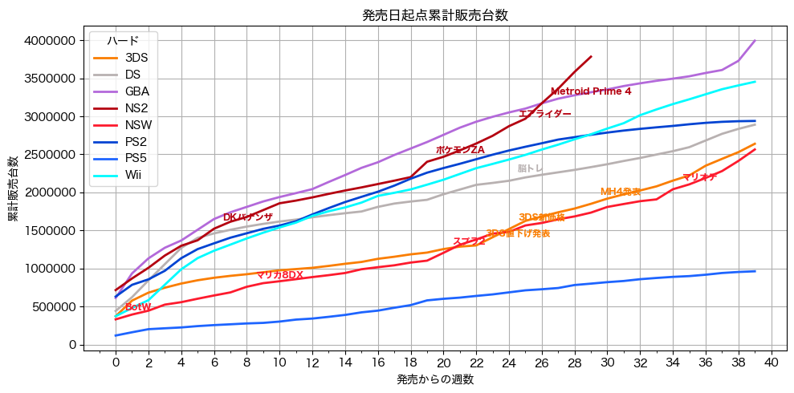

| ハード | 週数 | 販売数 |
| --- | --- | --- |
| NS2 | 29 | 3,784,067 |
| GBA | 29 | 3,316,352 |
| Wii | 29 | 2,764,123 |
| PS2 | 29 | 2,757,379 |
| DS | 29 | 2,332,198 |
| 3DS | 29 | 1,849,714 |
| NSW | 29 | 1,734,083 |
| PS5 | 29 | 800,380 |

### Switch(2017)とSwitch2(2025)年末商戦の比較

海外でSwitch2がSwitchの最初のホリデーシーズンを下回った報道が流れてますが､日本の状況を振り返ってみましょう｡

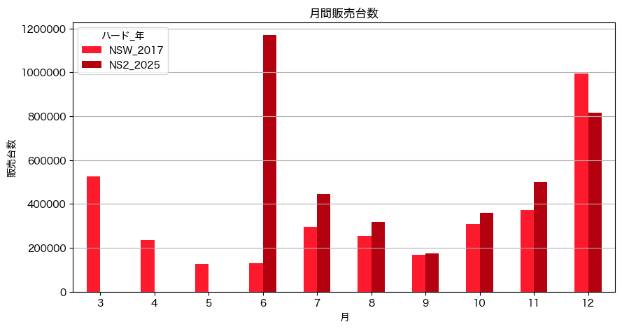

| hw month | NSW_2017 | NS2_2025 |
| --- | --- | --- |
| 11 | 372,619 | 500,414 |
| 12 | 993,318 | 815,632 |
| 合計 | 1,365,937 | 1,316,046 |

まず､12月同士の比較では18万台差でSwitchがSwitch2を上回っています｡ ただし2017年12月は5回集計､2025年12月は4回集計なので差が出ます｡ そこで11月まで含めて9週間で比較すると... それでもSwitchの方が5万台多い結果となります｡

というわけで､日本でも「Switch2の年末商戦はSwitchのそれを下回った」は事実です｡ しかし､その差は僅かであり､Switch2の夏季中の出荷の多さを考えると､ Switch2は需要の強さを鑑みて年末集中よりは､ 早くから太めの出荷を行ったと見るべきでしょう｡

前記のように30週間での初動台数はSwitchの倍以上のペースであり､ 需要の強さは圧倒的と言えます｡

## 年単位の状況

2025年の販売台数は621万台でした｡ 2022年の626万台にはギリ届来ませんでしたが､2018,2019年を超える事ができました｡

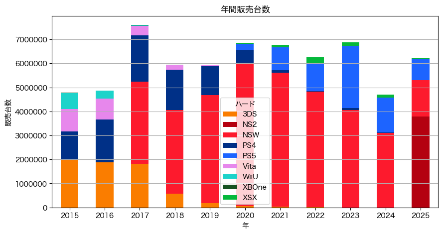

| hw year | 3DS | NS2 | NSW | PS4 | PS5 | Vita | WiiU | XBOne | XSX | sum |
| --- | --- | --- | --- | --- | --- | --- | --- | --- | --- | --- |
| 2015 | 1980598.0 | 0.0 | 0.0 | 1190336.0 | 0.0 | 920025.0 | 678131.0 | 17065.0 | 0.0 | 4786155.0 |
| 2016 | 1874457.0 | 0.0 | 0.0 | 1790883.0 | 0.0 | 865002.0 | 336151.0 | 8897.0 | 0.0 | 4875390.0 |
| 2017 | 1827131.0 | 0.0 | 3407158.0 | 1935247.0 | 0.0 | 396207.0 | 21817.0 | 14664.0 | 0.0 | 7602224.0 |
| 2018 | 566420.0 | 0.0 | 3482388.0 | 1695227.0 | 0.0 | 181728.0 | 0.0 | 15339.0 | 0.0 | 5941102.0 |
| 2019 | 191173.0 | 0.0 | 4493903.0 | 1196153.0 | 0.0 | 37668.0 | 0.0 | 8315.0 | 0.0 | 5927212.0 |
| 2020 | 62761.0 | 0.0 | 5956943.0 | 542647.0 | 255150.0 | 0.0 | 0.0 | 3585.0 | 31424.0 | 6852510.0 |
| 2021 | 28540.0 | 0.0 | 5579127.0 | 104054.0 | 968185.0 | 0.0 | 0.0 | 0.0 | 97234.0 | 6777140.0 |
| 2022 | 10664.0 | 0.0 | 4804546.0 | 22823.0 | 1154054.0 | 0.0 | 0.0 | 0.0 | 269737.0 | 6261824.0 |
| 2023 | 3033.0 | 0.0 | 4062609.0 | 73292.0 | 2587468.0 | 0.0 | 0.0 | 0.0 | 141712.0 | 6868114.0 |
| 2024 | 162.0 | 0.0 | 3109103.0 | 13728.0 | 1454149.0 | 0.0 | 0.0 | 0.0 | 118221.0 | 4695363.0 |
| 2025 | 0.0 | 3784067.0 | 1520384.0 | 1087.0 | 879204.0 | 0.0 | 0.0 | 0.0 | 31226.0 | 6215968.0 |

### 任天堂の年単位状況

2025年の任天堂のハード販売台数は530万台でした｡ 4年ぶりに500万台を超えて､2017年の525万台も超えました｡

2026年はSwitchの減少が予想されますが､ 通年で販売するSwitch2がその減少分を補って､合計で600万台を超えるかも知れません｡

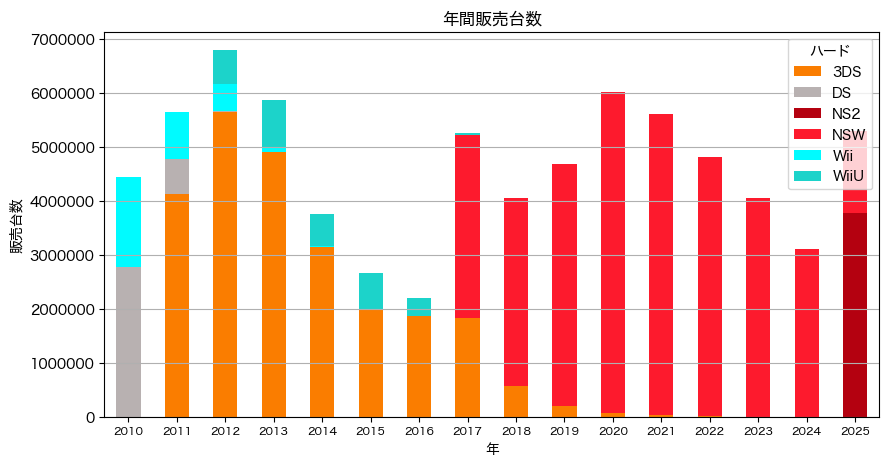

| hw year | 3DS | DS | NS2 | NSW | Wii | WiiU | sum |
| --- | --- | --- | --- | --- | --- | --- | --- |
| 2010 | 0.0 | 2785954.0 | 0.0 | 0.0 | 1651288.0 | 0.0 | 4437242.0 |
| 2011 | 4132038.0 | 648509.0 | 0.0 | 0.0 | 873406.0 | 0.0 | 5653953.0 |
| 2012 | 5646213.0 | 27662.0 | 0.0 | 0.0 | 491659.0 | 635290.0 | 6800824.0 |
| 2013 | 4912059.0 | 0.0 | 0.0 | 0.0 | 78677.0 | 883137.0 | 5873873.0 |
| 2014 | 3153045.0 | 0.0 | 0.0 | 0.0 | 7187.0 | 604856.0 | 3765088.0 |
| 2015 | 1980598.0 | 0.0 | 0.0 | 0.0 | 0.0 | 678131.0 | 2658729.0 |
| 2016 | 1874457.0 | 0.0 | 0.0 | 0.0 | 0.0 | 336151.0 | 2210608.0 |
| 2017 | 1827131.0 | 0.0 | 0.0 | 3407158.0 | 0.0 | 21817.0 | 5256106.0 |
| 2018 | 566420.0 | 0.0 | 0.0 | 3482388.0 | 0.0 | 0.0 | 4048808.0 |
| 2019 | 191173.0 | 0.0 | 0.0 | 4493903.0 | 0.0 | 0.0 | 4685076.0 |
| 2020 | 62761.0 | 0.0 | 0.0 | 5956943.0 | 0.0 | 0.0 | 6019704.0 |
| 2021 | 28540.0 | 0.0 | 0.0 | 5579127.0 | 0.0 | 0.0 | 5607667.0 |
| 2022 | 10664.0 | 0.0 | 0.0 | 4804546.0 | 0.0 | 0.0 | 4815210.0 |
| 2023 | 3033.0 | 0.0 | 0.0 | 4062609.0 | 0.0 | 0.0 | 4065642.0 |
| 2024 | 162.0 | 0.0 | 0.0 | 3109103.0 | 0.0 | 0.0 | 3109265.0 |
| 2025 | 0.0 | 0.0 | 3784067.0 | 1520384.0 | 0.0 | 0.0 | 5304451.0 |

### SONYの年間販売台数推移

2025年のPlayStationは88万台でした｡ これは2020年の79万台に次ぐ低い値です｡

噂されるPS6登場まで2年以上空く状況で100万台を切ったPS5が､2026年をどう生き延びるか､注目です｡

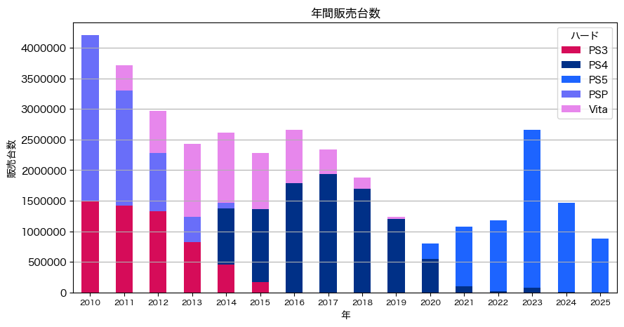

| hw year | PS3 | PS4 | PS5 | PSP | Vita | sum |
| --- | --- | --- | --- | --- | --- | --- |
| 2010 | 1500659.0 | 0.0 | 0.0 | 2704976.0 | 0.0 | 4205635.0 |
| 2011 | 1414745.0 | 0.0 | 0.0 | 1889806.0 | 402794.0 | 3707345.0 |
| 2012 | 1332548.0 | 0.0 | 0.0 | 951496.0 | 680895.0 | 2964939.0 |
| 2013 | 818804.0 | 0.0 | 0.0 | 419889.0 | 1191450.0 | 2430143.0 |
| 2014 | 450304.0 | 925570.0 | 0.0 | 83891.0 | 1147936.0 | 2607701.0 |
| 2015 | 166343.0 | 1190336.0 | 0.0 | 0.0 | 920025.0 | 2276704.0 |
| 2016 | 0.0 | 1790883.0 | 0.0 | 0.0 | 865002.0 | 2655885.0 |
| 2017 | 0.0 | 1935247.0 | 0.0 | 0.0 | 396207.0 | 2331454.0 |
| 2018 | 0.0 | 1695227.0 | 0.0 | 0.0 | 181728.0 | 1876955.0 |
| 2019 | 0.0 | 1196153.0 | 0.0 | 0.0 | 37668.0 | 1233821.0 |
| 2020 | 0.0 | 542647.0 | 255150.0 | 0.0 | 0.0 | 797797.0 |
| 2021 | 0.0 | 104054.0 | 968185.0 | 0.0 | 0.0 | 1072239.0 |
| 2022 | 0.0 | 22823.0 | 1154054.0 | 0.0 | 0.0 | 1176877.0 |
| 2023 | 0.0 | 73292.0 | 2587468.0 | 0.0 | 0.0 | 2660760.0 |
| 2024 | 0.0 | 13728.0 | 1454149.0 | 0.0 | 0.0 | 1467877.0 |
| 2025 | 0.0 | 1087.0 | 879204.0 | 0.0 | 0.0 | 880291.0 |

### Microsoftの年間販売台数推移

2025年のXbox Series X|Sは31226台｡ 前年比26%の大ブレーキでした｡2026年は1万台程度に低下しそうです｡

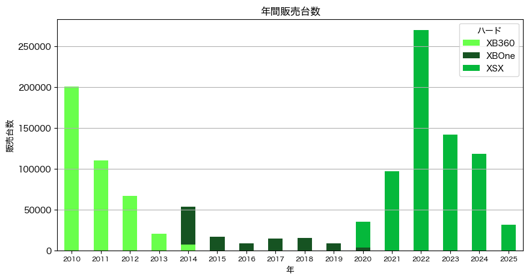

| hw year | XB360 | XBOne | XSX | sum |
| --- | --- | --- | --- | --- |
| 2010 | 200872.0 | 0.0 | 0.0 | 200872.0 |
| 2011 | 110034.0 | 0.0 | 0.0 | 110034.0 |
| 2012 | 66764.0 | 0.0 | 0.0 | 66764.0 |
| 2013 | 20057.0 | 0.0 | 0.0 | 20057.0 |
| 2014 | 7381.0 | 45958.0 | 0.0 | 53339.0 |
| 2015 | 0.0 | 17065.0 | 0.0 | 17065.0 |
| 2016 | 0.0 | 8897.0 | 0.0 | 8897.0 |
| 2017 | 0.0 | 14664.0 | 0.0 | 14664.0 |
| 2018 | 0.0 | 15339.0 | 0.0 | 15339.0 |
| 2019 | 0.0 | 8315.0 | 0.0 | 8315.0 |
| 2020 | 0.0 | 3585.0 | 31424.0 | 35009.0 |
| 2021 | 0.0 | 0.0 | 97234.0 | 97234.0 |
| 2022 | 0.0 | 0.0 | 269737.0 | 269737.0 |
| 2023 | 0.0 | 0.0 | 141712.0 | 141712.0 |
| 2024 | 0.0 | 0.0 | 118221.0 | 118221.0 |
| 2025 | 0.0 | 0.0 | 31226.0 | 31226.0 |

### 年単位のメーカーシェア

任天堂のシェアがさらに上昇し､85.3%で2025年は完了しました｡

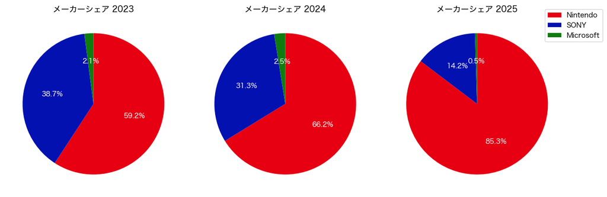